# Chapter 8: Tree-Based Methods

Paulo Loyola

Loads the libraries:

```r
library(class)
library(tree)
library(randomForest)
library(gbm)
library(ISLR)
library(MASS)
library(leaps)
```

**7)**

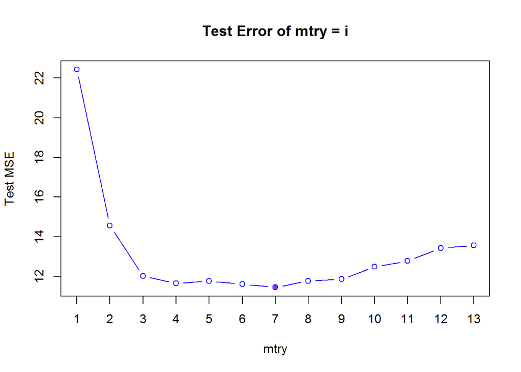

```r
set.seed(1)
train = sample(1:nrow(Boston), nrow(Boston)/2)
boston.test = Boston[-train, "medv"]
test.error = c()
for(i in 1:13){
  model = randomForest(medv ~ ., data = Boston, subset = train, mtry = i, importance = TRUE)
  yhat.bag = predict(model, newdata = Boston[-train,])
  test.error[i] = mean((yhat.bag - boston.test) ^ 2)
}
plot(test.error ~ c(1:13), ylab = "Test MSE", xlab = "mtry", col = "blue", type = "b", main = "Test Error of mtry = i", xaxt = "n")
axis(1, xaxp=c(0, 13, 13))
points(which.min(test.error), test.error[which.min(test.error)], col = "purple", pch = 20)
```

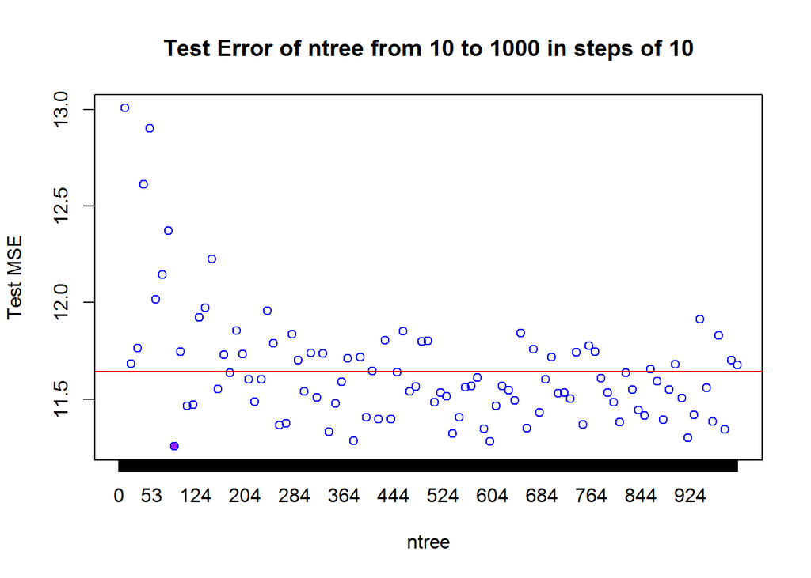

```r
set.seed(1)
train = sample(1:nrow(Boston), nrow(Boston)/2)
boston.test = Boston[-train, "medv"]
test.error = c()
for( i in seq(10, 1000, 10)){
  model = randomForest(medv ~., data = Boston, subset = train, mtry = 7, ntree = i, importance = TRUE)
  yhat.bag = predict(model, newdata = Boston[-train,])
  test.error[i] = mean((yhat.bag - boston.test) ^ 2)
}
plot(test.error ~ c(1:1000), ylab = "Test MSE", xlab = "ntree", col = "blue", type = "b", main = "Test Error of ntree from 10 to 1000 in steps of 10", xaxt = "n")
axis(1, xaxp = c(0, 1000, 1000))
points(which.min(test.error), test.error[which.min(test.error)], col = "purple", pch = 20)
abline(h=mean(test.error, na.rm=TRUE), col="red")
```

```r
print(which.min(test.error))
```

```
## [1] 90
```

```r
print(test.error[90])
```

```
## [1] 11.25494
```

Analyzing the results we can see that the best value of mtry is 7. This means that 7 (out of 13) predictors should be considered in each split of the tree. Looking at the results for ntree, we can see that the smallest number os trees are the ones with the highest test errors and that the optimal number of trees is 90. However, we should remember that we only considered trees in multiples of ten, so it’s possible that the number of trees that are actually optimal is different than 90.

**8)**

** a), b) and c)**

```r
set.seed(1)
train = sample(1:nrow(Carseats), nrow(Carseats)/2)
test = Carseats[-train,]
train = Carseats[train,]
tree.carseats = tree(Sales ~., train)
summary(tree.carseats)
```

```
##
## Regression tree:
## tree(formula = Sales ~ ., data = train)
## Variables actually used in tree construction:
## [1] "ShelveLoc"   "Price"       "Age"         "Advertising" "Income"
## [6] "CompPrice"
## Number of terminal nodes:  18
## Residual mean deviance:  2.36 = 429.5 / 182
## Distribution of residuals:
##    Min. 1st Qu.  Median    Mean 3rd Qu.    Max.
## -4.2570 -1.0360  0.1024  0.0000  0.9301  3.9130
```

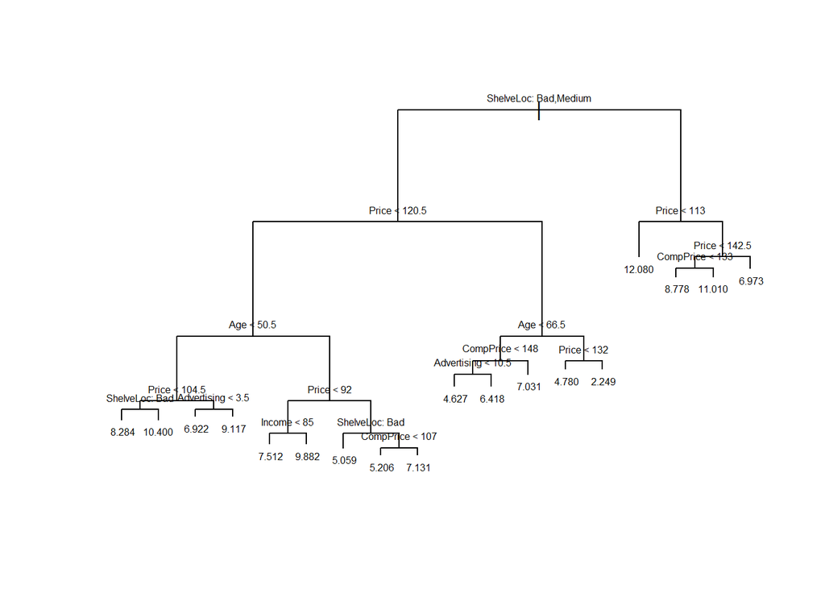

```r
plot(tree.carseats)
text(tree.carseats, pretty = 0, cex = 0.5)
```

```r
tree.pred = predict(tree.carseats, test)
mean((tree.pred - test[,"Sales"])^2)
```

```
## [1] 4.148897
```

We’ve got a MSE of 4.15.

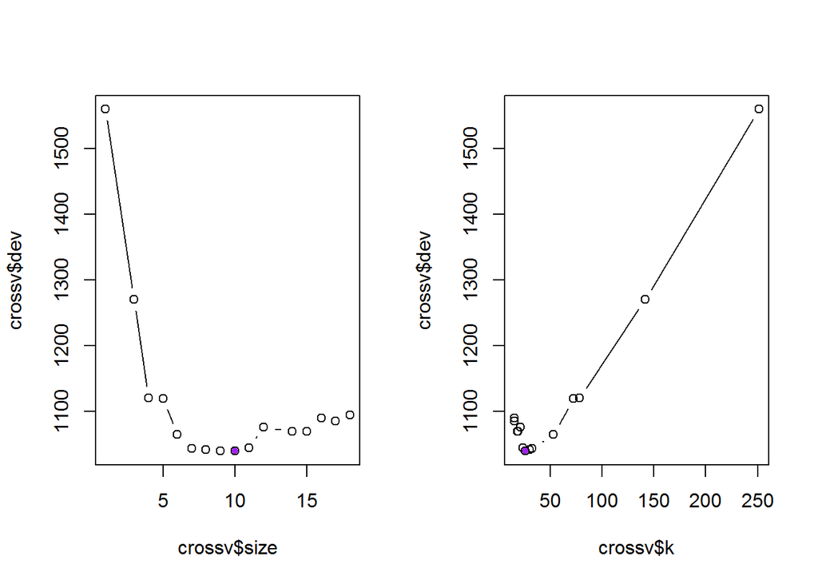

```r
crossv = cv.tree(tree.carseats, FUN = prune.tree)
par(mfrow = c(1, 2))
plot(crossv$size, crossv$dev, type = "b")
points(crossv$size[which.min(crossv$dev)], crossv$dev[which.min(crossv$dev)], col = "purple", pch = 20)
plot(crossv$k, crossv$dev, type = "b")
points(crossv$k[which.min(crossv$dev)], crossv$dev[which.min(crossv$dev)], col = "purple", pch = 20)
```

```r
crossv$size[which.min(crossv$dev)]
```

```
## [1] 10
```

```r
crossv$k[which.min(crossv$dev)]
```

```
## [1] 25.78579
```

**d)**

```r
bagging = randomForest(Sales ~., train, mtry=10, importance = TRUE)
bagging
```

```
##
## Call:
##  randomForest(formula = Sales ~ ., data = train, mtry = 10, importance = TRUE)
##                Type of random forest: regression
##                      Number of trees: 500
## No. of variables tried at each split: 10
##
##           Mean of squared residuals: 2.811039
##                     % Var explained: 63.17
```

```r
bagging.pred = predict(bagging, test)
mean((bagging.pred - test[,"Sales"])^2)
```

```
## [1] 2.633915
```

```r
importance(bagging)
```

```
##                %IncMSE IncNodePurity
## CompPrice   16.9874366    126.852848
## Income       3.8985402     78.314126
## Advertising 16.5698586    123.702901
## Population   0.6487058     62.328851
## Price       55.3976775    514.654890
## ShelveLoc   42.7849818    319.133777
## Age         20.5135255    185.582077
## Education    3.4615211     42.253410
## Urban       -2.5125087      8.700009
## US           7.3586645     18.180651
```

We can see that the variables Price, ShelveLoc and Age are the most important variables to understand Sales.

** e) **

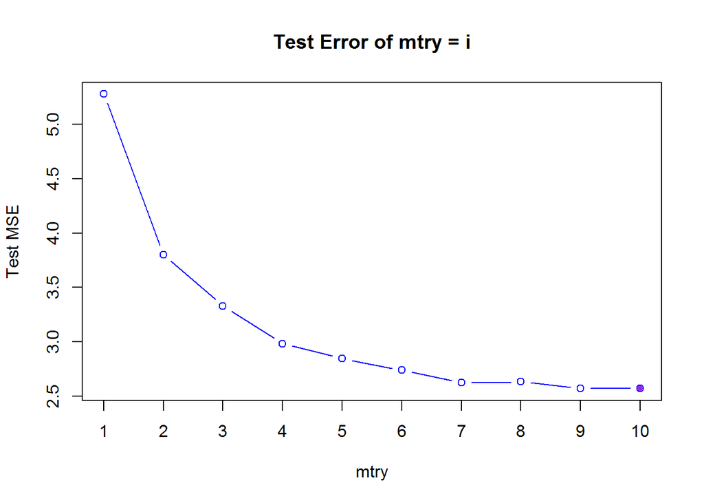

```r
set.seed(1)
test.error = c()
for(i in 1:10){
  model = randomForest(Sales ~ ., data = train, mtry = i, importance = TRUE)
  yhat.bag = predict(model, test)
  test.error[i] = mean((yhat.bag - test$Sales) ^ 2)
}
plot(test.error ~ c(1:10), ylab = "Test MSE", xlab = "mtry", col = "blue", type = "b", main = "Test Error of mtry = i", xaxt = "n")
axis(1, xaxp=c(0, 10, 10))
points(which.min(test.error), test.error[which.min(test.error)], col = "purple", pch = 20)
```

```r
set.seed(1)
rforest = randomForest(Sales ~ ., data = train, mtry = 3, importance = TRUE)
rforest
```

```
##
## Call:
##  randomForest(formula = Sales ~ ., data = train, mtry = 3, importance = TRUE)
##                Type of random forest: regression
##                      Number of trees: 500
## No. of variables tried at each split: 3
##
##           Mean of squared residuals: 3.221106
##                     % Var explained: 57.8
```

```r
rforest.pred = predict(rforest, test)
mean((rforest.pred - test[,"Sales"])^2)
```

```
## [1] 3.237463
```

```r
importance(rforest)
```

```
##                %IncMSE IncNodePurity
## CompPrice    8.0753055     122.68542
## Income       4.7774822     128.79339
## Advertising 12.6417009     139.29703
## Population   0.6016753      94.79730
## Price       37.6994519     382.76169
## ShelveLoc   32.8805652     239.26395
## Age         17.6866850     208.74153
## Education    0.4932141      66.98484
## Urban        0.5287570      16.29274
## US           7.8534356      31.39177
```

```r
set.seed(1)
rforest = randomForest(Sales ~ ., data = train, mtry = 7, importance = TRUE)
rforest
```

```
##
## Call:
##  randomForest(formula = Sales ~ ., data = train, mtry = 7, importance = TRUE)
##                Type of random forest: regression
##                      Number of trees: 500
## No. of variables tried at each split: 7
##
##           Mean of squared residuals: 2.890375
##                     % Var explained: 62.13
```

```r
rforest.pred = predict(rforest, test)
mean((rforest.pred - test[,"Sales"])^2)
```

```
## [1] 2.642061
```

```r
importance(rforest)
```

```
##                 %IncMSE IncNodePurity
## CompPrice   11.61070673    128.817451
## Income       5.86664610     89.930486
## Advertising 15.10485252    132.140446
## Population  -0.05028697     66.596766
## Price       48.76041211    481.922680
## ShelveLoc   41.24861724    294.693176
## Age         19.49641488    194.824043
## Education    1.15087357     47.311885
## Urban       -1.89894210      9.778379
## US           5.65242643     20.632767
```

In a randomForest model that considers only 3 variables at each node, we’ve got a test MSE of 3.24. As observed looking at the test errors plot, by choosing to consider 7 variables at each node of the tree the test MSE is reduced to 2.64 and it is very close to the minimum value observed when mtry = 10 (the bagging model). It should be noticed that the most important variables are the same in the randomForest models and in the Bagging model.

**9)** **a)**

```r
set.seed(1)
train = sample(1:nrow(OJ), 800)
test = OJ[-train,]
train = OJ[train,]
```

**b)**

```r
treemodel = tree(Purchase ~., train)
summary(treemodel)
```

```
##
## Classification tree:
## tree(formula = Purchase ~ ., data = train)
## Variables actually used in tree construction:
## [1] "LoyalCH"       "PriceDiff"     "SpecialCH"     "ListPriceDiff"
## Number of terminal nodes:  8
## Residual mean deviance:  0.7305 = 578.6 / 792
## Misclassification error rate: 0.165 = 132 / 800
```

This model presents a training error rate of 0.165. And the tree has 8 terminal nodes.

**c)**

```r
treemodel
```

```
## node), split, n, deviance, yval, (yprob)
##       * denotes terminal node
##
##  1) root 800 1064.00 CH ( 0.61750 0.38250 )
##    2) LoyalCH < 0.508643 350  409.30 MM ( 0.27143 0.72857 )
##      4) LoyalCH < 0.264232 166  122.10 MM ( 0.12048 0.87952 )
##        8) LoyalCH < 0.0356415 57   10.07 MM ( 0.01754 0.98246 ) *
##        9) LoyalCH > 0.0356415 109  100.90 MM ( 0.17431 0.82569 ) *
##      5) LoyalCH > 0.264232 184  248.80 MM ( 0.40761 0.59239 )
##       10) PriceDiff < 0.195 83   91.66 MM ( 0.24096 0.75904 )
##         20) SpecialCH < 0.5 70   60.89 MM ( 0.15714 0.84286 ) *
##         21) SpecialCH > 0.5 13   16.05 CH ( 0.69231 0.30769 ) *
##       11) PriceDiff > 0.195 101  139.20 CH ( 0.54455 0.45545 ) *
##    3) LoyalCH > 0.508643 450  318.10 CH ( 0.88667 0.11333 )
##      6) LoyalCH < 0.764572 172  188.90 CH ( 0.76163 0.23837 )
##       12) ListPriceDiff < 0.235 70   95.61 CH ( 0.57143 0.42857 ) *
##       13) ListPriceDiff > 0.235 102   69.76 CH ( 0.89216 0.10784 ) *
##      7) LoyalCH > 0.764572 278   86.14 CH ( 0.96403 0.03597 ) *
```

**d)**

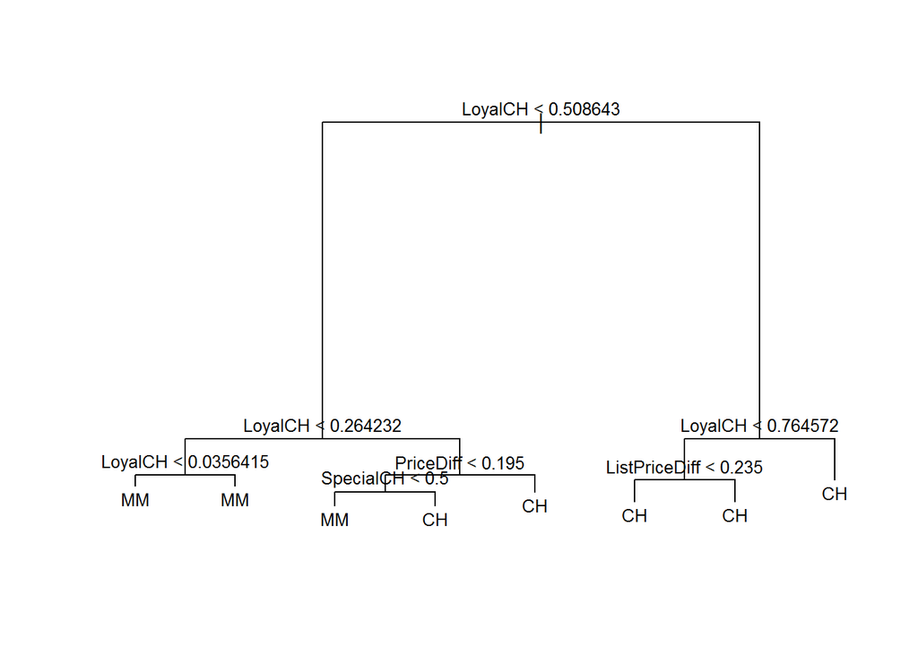

```r
plot(treemodel)
text(treemodel, pretty = 0, cex = 0.8)
```

Loyal is the most important variable since this variable is in the top nodes.

**e)**

```r
tree.pred = predict(treemodel, test, type = "class")
table(tree.pred, test$Purchase)
```

```
##
## tree.pred  CH  MM
##        CH 147  49
##        MM  12  62
```

```r
1 - (147+62)/nrow(test) # Test error rate.
```

```
## [1] 0.2259259
```

**f), g) and h)**

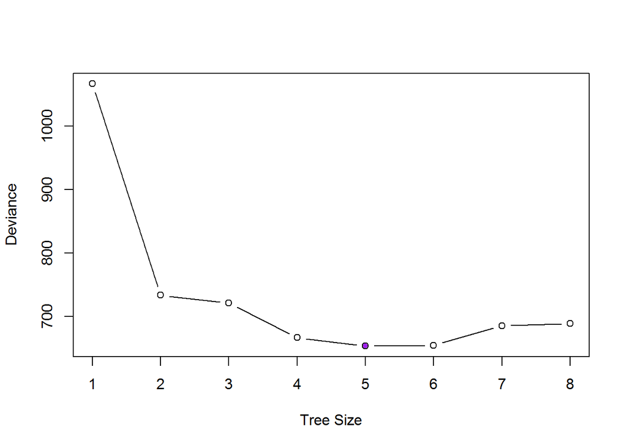

```r
crossv = cv.tree(treemodel, FUN = prune.tree)
plot(crossv$size, crossv$dev, type = "b", xlab = "Tree Size", ylab = "Deviance")
points(crossv$size[which.min(crossv$dev)], crossv$dev[which.min(crossv$dev)], col = "purple", pch = 20)
```

**i) and j)**

```r
prunedmodel = prune.tree(treemodel, best = 5)
summary(prunedmodel)
```

```
##
## Classification tree:
## snip.tree(tree = treemodel, nodes = 4:5)
## Variables actually used in tree construction:
## [1] "LoyalCH"       "ListPriceDiff"
## Number of terminal nodes:  5
## Residual mean deviance:  0.7829 = 622.4 / 795
## Misclassification error rate: 0.1825 = 146 / 800
```

The classification error of the unpruned tree is $0.165$ and the classification error of the pruned tree is $0.1825$.

**k)**

```r
tree.pred2 = predict(prunedmodel, test, type = "class")
table(tree.pred2, test$Purchase)
```

```
##
## tree.pred2  CH  MM
##         CH 119  30
##         MM  40  81
```

```r
1 - (119+81)/nrow(test) # Test error rate.
```

```
## [1] 0.2592593
```

The test error of the unpruned tree is $22.59\%$ while the test error of the pruned tree is $25.93\%$.

**10)** ** a)**

```r
hitters = Hitters[complete.cases(Hitters[, "Salary"]),]
hitters$Salary = log(hitters$Salary)
```

**b)**

```r
train = hitters[1:200,]
test = hitters[201:nrow(hitters),]
```

**c) and d)**

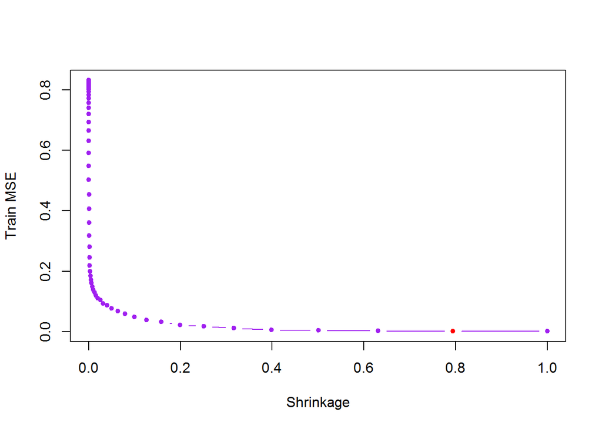

```r
set.seed(1)
power = seq(-10, 0, by = 0.1)
lambdas = 10^power
train.errors = rep(NA, length(lambdas))
test.errors = rep(NA, length(lambdas))
for (i in 1:length(lambdas)) {
  boosting = gbm(Salary ~ ., train, distribution = "gaussian", n.trees = 1000, shrinkage = lambdas[i])
  train.pred = predict(boosting, train, n.trees = 1000)
  test.pred = predict(boosting, test, n.trees = 1000)
  train.errors[i] = mean((train$Salary - train.pred)^2)
  test.errors[i] = mean((test$Salary - test.pred)^2)
}

plot(lambdas, train.errors, type = "b", xlab = "Shrinkage", ylab = "Train MSE", col = "purple", pch = 20)
points(lambdas[which.min(train.errors)], train.errors[which.min(train.errors)], col = "red", pch = 20)
```

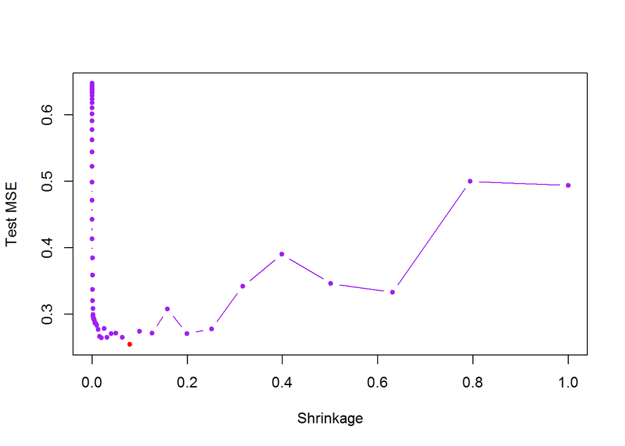

```r
plot(lambdas, test.errors, type = "b", xlab = "Shrinkage", ylab = "Test MSE", col = "purple", pch = 20)
points(lambdas[which.min(test.errors)], test.errors[which.min(test.errors)], col = "red", pch = 20)
```

```r
min(test.errors)
```

```
## [1] 0.2540265
```

** e)**

```r
linearmodel = lm(Salary ~., train)
linearpred = predict(linearmodel, test)
mean((linearpred - test$Salary)^2)
```

```
## [1] 0.4917959
```

```r
bestsub = regsubsets(Salary ~., train, nvmax = 19)
summary(bestsub)
```

```
## Subset selection object
## Call: regsubsets.formula(Salary ~ ., train, nvmax = 19)
## 19 Variables  (and intercept)
##            Forced in Forced out
## AtBat          FALSE      FALSE
## Hits           FALSE      FALSE
## HmRun          FALSE      FALSE
## Runs           FALSE      FALSE
## RBI            FALSE      FALSE
## Walks          FALSE      FALSE
## Years          FALSE      FALSE
## CAtBat         FALSE      FALSE
## CHits          FALSE      FALSE
## CHmRun         FALSE      FALSE
## CRuns          FALSE      FALSE
## CRBI           FALSE      FALSE
## CWalks         FALSE      FALSE
## LeagueN        FALSE      FALSE
## DivisionW      FALSE      FALSE
## PutOuts        FALSE      FALSE
## Assists        FALSE      FALSE
## Errors         FALSE      FALSE
## NewLeagueN     FALSE      FALSE
## 1 subsets of each size up to 19
## Selection Algorithm: exhaustive
##           AtBat Hits HmRun Runs RBI Walks Years CAtBat CHits CHmRun CRuns
## 1  ( 1 )  " "   " "  " "   " "  " " " "   " "   " "    " "   " "    " "
## 2  ( 1 )  " "   "*"  " "   " "  " " " "   "*"   " "    " "   " "    " "
## 3  ( 1 )  " "   "*"  " "   " "  " " " "   "*"   " "    " "   " "    " "
## 4  ( 1 )  " "   "*"  " "   " "  " " " "   "*"   " "    " "   " "    "*"
## 5  ( 1 )  "*"   "*"  " "   " "  " " "*"   "*"   " "    " "   " "    " "
## 6  ( 1 )  "*"   "*"  " "   " "  " " "*"   "*"   " "    " "   " "    "*"
## 7  ( 1 )  "*"   "*"  " "   " "  " " "*"   "*"   " "    " "   " "    "*"
## 8  ( 1 )  "*"   "*"  " "   " "  " " "*"   "*"   " "    " "   " "    "*"
## 9  ( 1 )  "*"   "*"  " "   " "  " " "*"   "*"   " "    " "   "*"    "*"
## 10  ( 1 ) "*"   "*"  " "   " "  " " "*"   "*"   " "    " "   "*"    "*"
## 11  ( 1 ) "*"   "*"  " "   " "  " " "*"   "*"   " "    " "   "*"    "*"
## 12  ( 1 ) "*"   "*"  " "   " "  " " "*"   "*"   " "    "*"   "*"    "*"
## 13  ( 1 ) "*"   "*"  " "   " "  " " "*"   "*"   " "    "*"   "*"    "*"
## 14  ( 1 ) "*"   "*"  " "   " "  " " "*"   "*"   "*"    "*"   "*"    "*"
```

[output cut: 10 more lines]

```
## 5  ( 1 )  " "  " "    " "     " "       "*"     " "     " "    " "
## 6  ( 1 )  " "  " "    " "     " "       "*"     " "     " "    " "
## 7  ( 1 )  " "  "*"    " "     " "       "*"     " "     " "    " "
## 8  ( 1 )  " "  "*"    " "     "*"       "*"     " "     " "    " "
## 9  ( 1 )  " "  "*"    " "     "*"       "*"     " "     " "    " "
## 10  ( 1 ) " "  "*"    " "     "*"       "*"     "*"     " "    " "
## 11  ( 1 ) " "  "*"    "*"     "*"       "*"     "*"     " "    " "
## 12  ( 1 ) " "  "*"    "*"     "*"       "*"     "*"     " "    " "
## 13  ( 1 ) " "  "*"    "*"     "*"       "*"     "*"     "*"    " "
## 14  ( 1 ) " "  "*"    "*"     "*"       "*"     "*"     "*"    " "
## 15  ( 1 ) " "  "*"    "*"     "*"       "*"     "*"     "*"    " "
## 16  ( 1 ) " "  "*"    "*"     "*"       "*"     "*"     "*"    " "
## 17  ( 1 ) "*"  "*"    "*"     "*"       "*"     "*"     "*"    " "
## 18  ( 1 ) "*"  "*"    "*"     "*"       "*"     "*"     "*"    "*"
## 19  ( 1 ) "*"  "*"    "*"     "*"       "*"     "*"     "*"    "*"
```

```r
summary(bestsub)$cp
```

```
##  [1] 83.616530 25.772706 17.912441 14.058117 10.175585  8.243160  7.274769
##  [8]  6.276534  6.763323  6.344524  6.972794  7.798123  8.812119 10.560088
## [15] 12.373938 14.262799 16.047388 18.013884 20.000000
```

```r
summary(bestsub)$bic
```

```
##  [1]  -92.18308 -135.04982 -138.93217 -139.29099 -139.84295 -138.55316
##  [7] -136.33481 -134.19632 -130.51193 -127.82076 -124.01624 -120.00604
## [13] -115.79540 -110.77606 -105.68404 -100.50899  -95.44981  -90.18871
## [19]  -84.90582
```

```r
summary(bestsub)$adjr2
```

```
##  [1] 0.3988199 0.5250866 0.5440796 0.5545221 0.5651341 0.5715547 0.5759048
##  [8] 0.5803669 0.5815487 0.5847828 0.5856803 0.5861388 0.5861704 0.5845135
## [15] 0.5826861 0.5806642 0.5788640 0.5766161 0.5742968
```

```r
# Choosing the best model according to the bic
bestsub = lm(Salary ~ AtBat + Hits + Walks + Years + PutOuts, train)
bestsubpred = predict(bestsub, test)
mean((bestsubpred - test$Salary)^2)
```

```
## [1] 0.4981346
```

The boosted model is the one with the smallest test MSE. It has a test MSE of $0.2540$. Meanwhile the test MSE of a linear model with all the variables is $0.4918$ and the test MSE of the best linear model with the lowest $BIC$ is $0.4981$.

**f)**

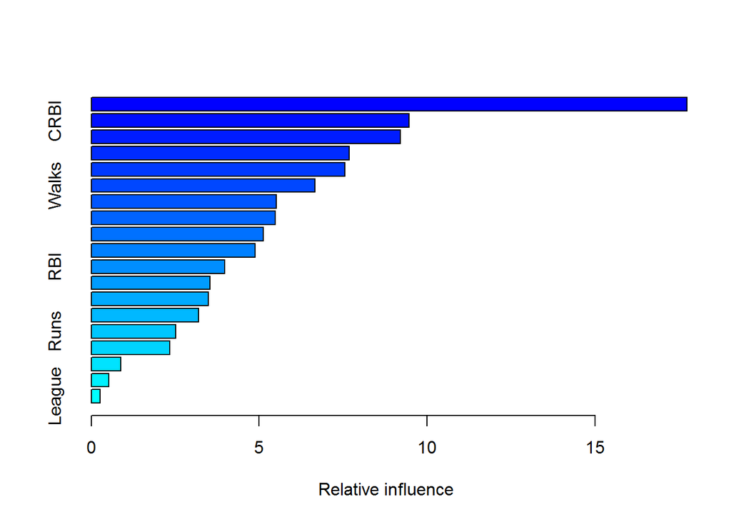

```
##                 var    rel.inf
## CAtBat       CAtBat 17.7405480
## CRBI           CRBI  9.4710629
## CWalks       CWalks  9.2087203
## CRuns         CRuns  7.6777611
## PutOuts     PutOuts  7.5498581
## Walks         Walks  6.6590705
## CHmRun       CHmRun  5.5064211
## Years         Years  5.4857911
## Assists     Assists  5.1179261
## CHits         CHits  4.8806844
## RBI             RBI  3.9726670
## Hits           Hits  3.5348054
## HmRun         HmRun  3.4862181
## AtBat         AtBat  3.1977256
## Runs           Runs  2.5121080
## Errors       Errors  2.3346181
## Division   Division  0.8777319
## NewLeague NewLeague  0.5267431
## League       League  0.2595391
```

```r
boosting = gbm(Salary ~ ., train, distribution = "gaussian", n.trees = 1000, shrinkage = lambdas[which.min(test.errors)])
summary(boosting)
```

$CAtBat$, $CRBI$ and $CWalks$ are, respectivelly, the most important predictors in the boosted model.

**g)**

```r
set.seed(1)
baggingmodel = randomForest(Salary ~., train, mtry = 19, ntree = 1000)
baggingmodel
```

```
##
## Call:
##  randomForest(formula = Salary ~ ., data = train, mtry = 19, ntree = 1000)
##                Type of random forest: regression
##                      Number of trees: 1000
## No. of variables tried at each split: 19
##
##           Mean of squared residuals: 0.2178518
##                     % Var explained: 73.82
```

```r
baggingpred = predict(baggingmodel, test)
mean((baggingpred - test$Salary) ^ 2)
```

```
## [1] 0.2300514
```

The Bagging Model has the smallest test MSE: $0.2301$.

**11)**